# Statistical Inference Course Project part 1

c zingler

19/05/2020

# Overview

Part 1 is a simulation exercise, in this part we will investigate the exponential distribution in R and compare it with the Central Limit Theorem. The exponential distribution can be simulated in R with rexp(n, lambda) where lambda is the rate parameter. The mean of exponential distribution is 1/lambda and the standard deviation is also 1/lambda. Set lambda = 0.2 for all of the simulations. You will investigate the distribution of averages of 40 generated exponentials.

## Tasks

We will need to do a thousand simulations. Illustrate the properties of the distribution of the mean of 40 exponentials generated. Show the sample mean and compare it to the theoretical mean of the distribution. Show how variable the sample is (via variance) and compare it to the theoretical variance of the distribution. Show that the distribution is approximately normal.

so the theoretical mean is 1/lambda = 1/0,2 = 5 = E[X] the theoretical standard deviation is also 5 so variance is 25 (5^2) = Xar(X) so Standard error = 5/sqrt(n).

## Simulations and Analysis

We have following setup The exponential distribution can be simulated in R with rexp(n, lambda) where lambda is the rate parameter. The mean of exponential distribution is 1/lambda and the standard deviation is also 1/lambda.

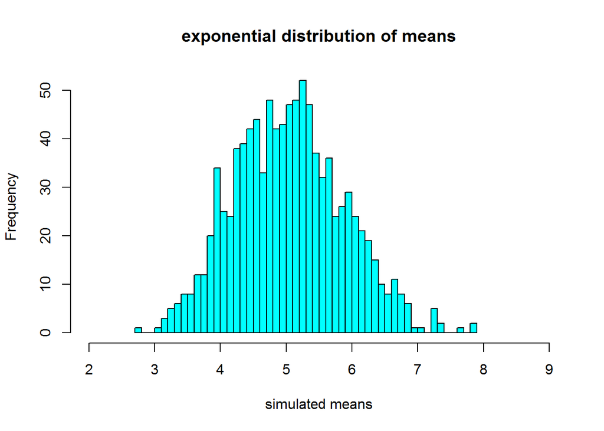

```r
# set the required parameters

lambda <- 0.2

N<-40

sims <-1000

# run the simulation
sim_exp <- replicate(sims,rexp(N,lambda), simplify = FALSE)

# convert by coertion the Matrix of listed results to a list of means
laggmeans <- lapply(sim_exp,mean)

# convert the list to a numeric vector also be coertion
naggmeans <- unlist(laggmeans)

# so the sample mean of the simulated distribution is
sample_meanexp <- mean(naggmeans)

#show a plot of the simulated mean density function
plotmean <- hist(naggmeans, breaks =  40,xlim = c(2,9),main = "exponential distribution of means",
col= "cyan", xlab = "simulated means")
```

```r
# now the theoretical mean is 1/lambda so
theo_mean <- 1/lambda

# lets look at the difference in means

diff_mean <- theo_mean-sample_meanexp

print(diff_mean)
```

```
## [1] -0.04040416
```

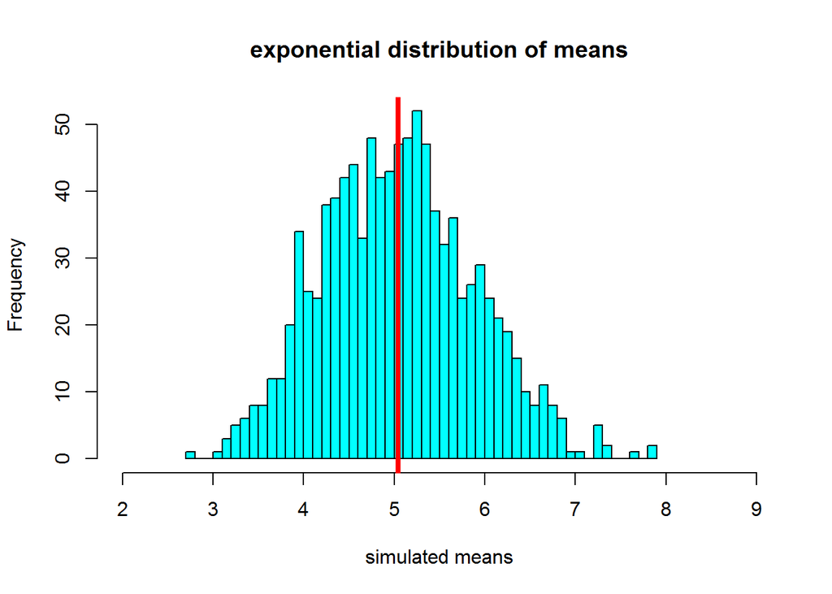

```r
# this difference (or mean comparision) is small


# Now plot density with mean hilighted
plotmean_point <- hist(naggmeans, breaks =  40,xlim = c(2,9),main = "exponential distribution of means",
col= "cyan", xlab = "simulated means")

plotmean_point <- abline(v= sample_meanexp,lwd= "4", col= "red")
```

```r
# Now lets do a variance comparision
Sample_var <- var(naggmeans)

#the sample variance is
print(Sample_var)
```

```
## [1] 0.6902489
```

```r
# and Theoretical Variance is
Theo_var <-(1/lambda)^2/N

print(Theo_var)
```

```
## [1] 0.625
```

```r
#So the difference in variance is
Diff_var <- Theo_var-Sample_var

#which is
print(Diff_var)
```

```
## [1] -0.0652489
```

```r
# the Difference is also quite small
```

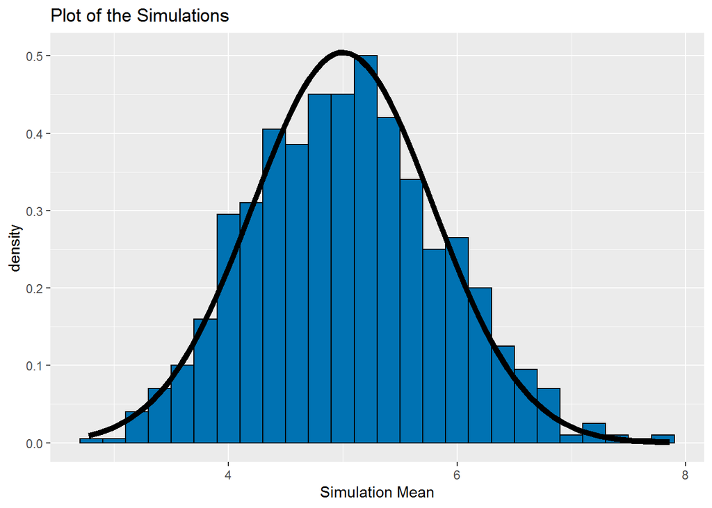

We can on inspection see the density function and the over laid normal curve match farly closely.

let look at the 95% confidence interval

```r
#So we need
1/lambda +c(-1,1)*1.96*(lambda^-1)/sqrt(N)
```

```
## [1] 3.450484 6.549516
```

As we can see this range covers most of the simulated density function.

# Conclusion

## The Central limits theorem

Is correct for this simulation.